# JX-backward

Jingyu Xu

2018/12/9

```r
#load and exculde redundant variable
can_reg = read.csv(file = "./Cancer_Registry.csv")
can_reg_omit = can_reg %>%
  janitor::clean_names() %>%
  select(-pct_some_col18_24, -pct_no_hs18_24, -pct_hs18_24, -pct_bach_deg18_24, -avg_ann_count, -avg_deaths_per_year, -med_income, -pop_est2015, -median_age_male, -median_age_female, -percent_married, -pct_employed16_over, -pct_private_coverage, -pct_private_coverage_alone, -pct_emp_priv_coverage, -pct_public_coverage, -pct_black, -pct_asian, -pct_other_race) %>%
  na.omit()%>%
  filter(median_age < 100)%>%
  select(geography, target_death_rate, binned_inc, everything())
```

```r
#description of raw dataset and cleaned dataset
summary(can_reg)
```

```
##   avgAnnCount      avgDeathsPerYear TARGET_deathRate incidenceRate
##  Min.   :    6.0   Min.   :    3    Min.   : 59.7    Min.   : 201.3
##  1st Qu.:   76.0   1st Qu.:   28    1st Qu.:161.2    1st Qu.: 420.3
##  Median :  171.0   Median :   61    Median :178.1    Median : 453.5
##  Mean   :  606.3   Mean   :  186    Mean   :178.7    Mean   : 448.3
##  3rd Qu.:  518.0   3rd Qu.:  149    3rd Qu.:195.2    3rd Qu.: 480.9
##  Max.   :38150.0   Max.   :14010    Max.   :362.8    Max.   :1206.9
##
##    medIncome        popEst2015       povertyPercent   studyPerCap
##  Min.   : 22640   Min.   :     827   Min.   : 3.20   Min.   :   0.00
##  1st Qu.: 38882   1st Qu.:   11684   1st Qu.:12.15   1st Qu.:   0.00
##  Median : 45207   Median :   26643   Median :15.90   Median :   0.00
##  Mean   : 47063   Mean   :  102637   Mean   :16.88   Mean   : 155.40
##  3rd Qu.: 52492   3rd Qu.:   68671   3rd Qu.:20.40   3rd Qu.:  83.65
##  Max.   :125635   Max.   :10170292   Max.   :47.40   Max.   :9762.31
##
##               binnedInc      MedianAge      MedianAgeMale
##  (45201, 48021.6]  : 306   Min.   : 22.30   Min.   :22.40
##  (54545.6, 61494.5]: 306   1st Qu.: 37.70   1st Qu.:36.35
##  [22640, 34218.1]  : 306   Median : 41.00   Median :39.60
##  (42724.4, 45201]  : 305   Mean   : 45.27   Mean   :39.57
##  (48021.6, 51046.4]: 305   3rd Qu.: 44.00   3rd Qu.:42.50
##  (51046.4, 54545.6]: 305   Max.   :624.00   Max.   :64.70
##  (Other)           :1214
##  MedianAgeFemale                            Geography    AvgHouseholdSize
##  Min.   :22.30   Abbeville County, South Carolina:   1   Min.   :0.0221
##  1st Qu.:39.10   Acadia Parish, Louisiana        :   1   1st Qu.:2.3700
##  Median :42.40   Accomack County, Virginia       :   1   Median :2.5000
##  Mean   :42.15   Ada County, Idaho               :   1   Mean   :2.4797
##  3rd Qu.:45.30   Adair County, Iowa              :   1   3rd Qu.:2.6300
##  Max.   :65.70   Adair County, Kentucky          :   1   Max.   :3.9700
##                  (Other)                         :3041
##  PercentMarried   PctNoHS18_24     PctHS18_24   PctSomeCol18_24
##  Min.   :23.10   Min.   : 0.00   Min.   : 0.0   Min.   : 7.10
##  1st Qu.:47.75   1st Qu.:12.80   1st Qu.:29.2   1st Qu.:34.00
##  Median :52.40   Median :17.10   Median :34.7   Median :40.40
##  Mean   :51.77   Mean   :18.22   Mean   :35.0   Mean   :40.98
##  3rd Qu.:56.40   3rd Qu.:22.70   3rd Qu.:40.7   3rd Qu.:46.40
##  Max.   :72.50   Max.   :64.10   Max.   :72.5   Max.   :79.00
##                                                 NA's   :2285
```

[output cut: 25 more lines]

```
##  Min.   : 10.20   Min.   : 0.0000   Min.   : 0.0000   Min.   : 0.0000
##  1st Qu.: 77.30   1st Qu.: 0.6207   1st Qu.: 0.2542   1st Qu.: 0.2952
##  Median : 90.06   Median : 2.2476   Median : 0.5498   Median : 0.8262
##  Mean   : 83.65   Mean   : 9.1080   Mean   : 1.2540   Mean   : 1.9835
##  3rd Qu.: 95.45   3rd Qu.:10.5097   3rd Qu.: 1.2210   3rd Qu.: 2.1780
##  Max.   :100.00   Max.   :85.9478   Max.   :42.6194   Max.   :41.9303
##
##  PctMarriedHouseholds   BirthRate
##  Min.   :22.99        Min.   : 0.000
##  1st Qu.:47.76        1st Qu.: 4.521
##  Median :51.67        Median : 5.381
##  Mean   :51.24        Mean   : 5.640
##  3rd Qu.:55.40        3rd Qu.: 6.494
##  Max.   :78.08        Max.   :21.326
##
```

```r
summary(can_reg_omit)
```

```
##                             geography    target_death_rate
##  Abbeville County, South Carolina:   1   Min.   : 59.7
##  Acadia Parish, Louisiana        :   1   1st Qu.:161.3
##  Accomack County, Virginia       :   1   Median :178.1
##  Ada County, Idaho               :   1   Mean   :178.6
##  Adair County, Iowa              :   1   3rd Qu.:195.2
##  Adair County, Kentucky          :   1   Max.   :362.8
##  (Other)                         :3011
##               binned_inc   incidence_rate   poverty_percent
##  (51046.4, 54545.6]: 304   Min.   : 201.3   Min.   : 3.20
##  [22640, 34218.1]  : 304   1st Qu.: 420.3   1st Qu.:12.20
##  (42724.4, 45201]  : 303   Median : 453.5   Median :15.80
##  (45201, 48021.6]  : 303   Mean   : 448.2   Mean   :16.88
##  (48021.6, 51046.4]: 303   3rd Qu.: 480.8   3rd Qu.:20.40
##  (54545.6, 61494.5]: 302   Max.   :1206.9   Max.   :47.40
##  (Other)           :1198
##  study_per_cap      median_age    avg_household_size pct_hs25_over
##  Min.   :   0.0   Min.   :22.30   Min.   :0.0221     Min.   : 7.50
##  1st Qu.:   0.0   1st Qu.:37.70   1st Qu.:2.3700     1st Qu.:30.40
##  Median :   0.0   Median :40.90   Median :2.5000     Median :35.30
##  Mean   : 156.6   Mean   :40.82   Mean   :2.4790     Mean   :34.81
##  3rd Qu.:  83.9   3rd Qu.:43.80   3rd Qu.:2.6300     3rd Qu.:39.70
##  Max.   :9762.3   Max.   :65.30   Max.   :3.9700     Max.   :54.80
##
##  pct_bach_deg25_over pct_unemployed16_over pct_public_coverage_alone
##  Min.   : 2.50       Min.   : 0.400        Min.   : 2.60
##  1st Qu.: 9.40       1st Qu.: 5.500        1st Qu.:14.80
##  Median :12.30       Median : 7.600        Median :18.80
##  Mean   :13.28       Mean   : 7.839        Mean   :19.24
##  3rd Qu.:16.10       3rd Qu.: 9.700        3rd Qu.:23.10
##  Max.   :42.20       Max.   :29.400        Max.   :46.60
##
##    pct_white      pct_married_households   birth_rate
##  Min.   : 10.20   Min.   :22.99          Min.   : 0.000
##  1st Qu.: 77.40   1st Qu.:47.78          1st Qu.: 4.525
##  Median : 90.06   Median :51.68          Median : 5.381
##  Mean   : 83.67   Mean   :51.25          Mean   : 5.639
##  3rd Qu.: 95.44   3rd Qu.:55.40          3rd Qu.: 6.492
##  Max.   :100.00   Max.   :78.08          Max.   :21.326
##
```

## Backward elimination (AIC based)

```r
#backward elimination
 can_reg_back = can_reg_omit%>%
  select(-geography)

initial_fit = lm(target_death_rate~., data = can_reg_back)
step(initial_fit, direction = "backward")
```

```
## Start:  AIC=18020.59
## target_death_rate ~ binned_inc + incidence_rate + poverty_percent +
##     study_per_cap + median_age + avg_household_size + pct_hs25_over +
##     pct_bach_deg25_over + pct_unemployed16_over + pct_public_coverage_alone +
##     pct_white + pct_married_households + birth_rate
##
##                             Df Sum of Sq     RSS   AIC
## - avg_household_size         1         7 1167595 18019
## - study_per_cap              1        16 1167605 18019
## - pct_white                  1       123 1167711 18019
## - poverty_percent            1       217 1167805 18019
## <none>                                   1167588 18021
## - pct_public_coverage_alone  1      3631 1171219 18028
## - pct_unemployed16_over      1      5148 1172736 18032
## - birth_rate                 1      5605 1173194 18033
## - pct_married_households     1      5743 1173331 18033
## - median_age                 1      8332 1175920 18040
## - binned_inc                 9     22352 1189940 18060
## - pct_hs25_over              1     22736 1190324 18077
## - pct_bach_deg25_over        1     25238 1192826 18083
## - incidence_rate             1    324645 1492233 18759
##
## Step:  AIC=18018.61
## target_death_rate ~ binned_inc + incidence_rate + poverty_percent +
##     study_per_cap + median_age + pct_hs25_over + pct_bach_deg25_over +
##     pct_unemployed16_over + pct_public_coverage_alone + pct_white +
##     pct_married_households + birth_rate
##
##                             Df Sum of Sq     RSS   AIC
## - study_per_cap              1        16 1167611 18017
## - pct_white                  1       131 1167727 18017
## - poverty_percent            1       216 1167811 18017
## <none>                                   1167595 18019
## - pct_public_coverage_alone  1      3710 1171305 18026
## - pct_unemployed16_over      1      5199 1172794 18030
## - birth_rate                 1      5605 1173200 18031
## - pct_married_households     1      5970 1173566 18032
## - median_age                 1      9188 1176784 18040
## - binned_inc                 9     22350 1189946 18058
## - pct_hs25_over              1     22729 1190324 18075
```

[output cut: 42 more lines]

```
## target_death_rate ~ binned_inc + incidence_rate + median_age +
##     pct_hs25_over + pct_bach_deg25_over + pct_unemployed16_over +
##     pct_public_coverage_alone + pct_married_households + birth_rate
##
##                             Df Sum of Sq     RSS   AIC
## <none>                                   1167908 18013
## - pct_public_coverage_alone  1      3535 1171444 18020
## - birth_rate                 1      5516 1173424 18026
## - pct_unemployed16_over      1      5629 1173537 18026
## - pct_married_households     1      8123 1176032 18032
## - median_age                 1     10829 1178738 18039
## - binned_inc                 9     29505 1197413 18071
## - pct_hs25_over              1     23482 1191390 18072
## - pct_bach_deg25_over        1     25522 1193431 18077
## - incidence_rate             1    331298 1499206 18765
```

```
##
## Call:
## lm(formula = target_death_rate ~ binned_inc + incidence_rate +
##     median_age + pct_hs25_over + pct_bach_deg25_over + pct_unemployed16_over +
##     pct_public_coverage_alone + pct_married_households + birth_rate,
##     data = can_reg_back)
##
## Coefficients:
##                  (Intercept)  binned_inc(37413.8, 40362.7]
##                     112.1261                       -2.6127
## binned_inc(40362.7, 42724.4]    binned_inc(42724.4, 45201]
##                      -5.0615                       -6.1464
##   binned_inc(45201, 48021.6]  binned_inc(48021.6, 51046.4]
##                      -7.2954                      -10.2232
## binned_inc(51046.4, 54545.6]  binned_inc(54545.6, 61494.5]
##                      -9.5620                       -8.3251
##  binned_inc(61494.5, 125635]    binned_inc[22640, 34218.1]
##                      -5.4612                        3.9253
##               incidence_rate                    median_age
##                       0.2014                       -0.4081
##                pct_hs25_over           pct_bach_deg25_over
##                       0.6696                       -1.1161
##        pct_unemployed16_over     pct_public_coverage_alone
##                       0.5657                        0.3251
##       pct_married_households                    birth_rate
##                      -0.3351                       -0.7065
```

After backward elimination, the final model is : target_death_rate ~ binned_inc + incidence_rate + median_age + pct_hs25_over + pct_bach_deg25_over + pct_unemployed16_over + pct_public_coverage_alone + pct_married_households + birth_rate

There are 9 variables in the model.

## Check the distribution of variables

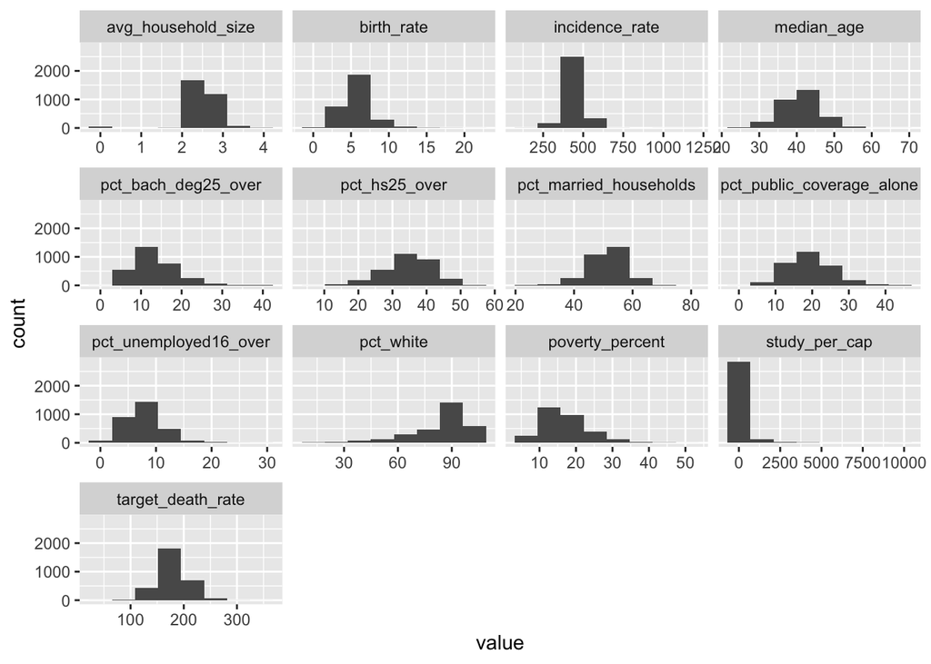

```r
##see the distribution of each variables

ggplot(gather(select(can_reg_back, -binned_inc)), aes(value)) +
    geom_histogram(bins = 8) +
    facet_wrap(~key, scales = 'free_x')
```

pct_white, poverty_percent and study_per_cap are a little skewed, other variables are nearly symmetric